# Activities with Tidy Data

Data Computing

September 7, 2015

*Rmd source file* ⇒ TidyDataActivities.Rmd

## Height measurements

In the 1880s, Francis Galton started to make a mathematical theory of evolution.

Here’s part of a page from his lab notebook. Translate it into tidy form.

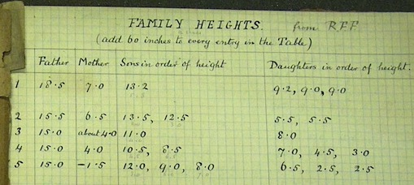

First, sketch out what the data table might look like:

- What are the variables?
- What are the cases?

In groups of 2 to 3, enter 10 or so cases into a spreadsheet such as Google spreadsheets.

- [Group-1](https://docs.google.com/spreadsheet/ccc?key=0Am13enSalO74dHNpejZtd3dQTXlPM245R0ZQbG0yYkE&usp=sharing)
- [Group-2](https://docs.google.com/spreadsheet/ccc?key=0Am13enSalO74dHk1enZoVnhrV09ad2x4dXR1MlpWNFE&usp=sharing)
- [Group-3](https://docs.google.com/spreadsheet/ccc?key=0Am13enSalO74dElIQkh0SWtyaW9aRkdMZVBERHdJNXc#gid=0)
- [Group-4](https://docs.google.com/spreadsheet/ccc?key=0Am13enSalO74dEYxdEhWZUI1S3NxN2ZaaThXSEtMVWc&usp=sharing)
- [Group-5](https://docs.google.com/spreadsheet/ccc?key=0Am13enSalO74dDVsLWJaUHV5emFVQlVfSjFrdmFkYXc&usp=sharing)
- [Group-6](https://docs.google.com/spreadsheet/ccc?key=0Am13enSalO74dFdvNGpFZkNuUHZqd2g2UEVDc0VEZEE&usp=sharing)

#### Instructors:

- Create several Google spreadsheets that are write-able to anyone with the link.
- Put the links in a place your students can access them.
- Direct the students to create their data table in one of the documents.

Some things to look for:

1. What is the case? For different groups, it might be an individual adult child or a family, etc.
2. The variable names. Make the point that, later on, students will want variables to be short, mnemonic, and without punctuation. Following the convention in the book, the initial letter should be lower case.
3. Putting labels and units into the table.
4. Some groups may be very far from tidiness, for instance allocating one set of columns to males and one to females, putting two individuals side-by-side rather than one individual on each line. Make sure to point this out and emphasise how this is not tidy.

## Marital status in the US armed forces

[This table](https://docs.google.com/spreadsheets/d/1Ow6Cm4z-Z1Yybk3i352msulYCEDOUaOghmo9ALajyHo/edit#gid=1811988794) is part of a study of personnel in the US armed forces, looking at family situation: marriage (to a civilian or another member of the armed forces) and children.

The “pay grade” reflects enlisted versus officer versus warrant officer (E vs O vs W). There are five sheets: Air Force, Marine Corps, Navy, and Army, as well as to total DoD (Department of Defense).

### Questions

- Describe ways in which the data are untidy.
- Which variables are a summary of other variables rather than being distinct measurements?
- Which rows are a summary of other rows?

This table might have been created as a summary of individual personnel records. What would the table containing the personnel records look like? Assume that the case is an individual member of the armed forces. (There are 1,414,951 people.)

- What should the variables be?
- For categorical variables, what are the levels?

## Voter participation

The spreadsheet [here](http://vote.minneapolismn.gov/www/groups/public/@clerk/documents/webcontent/wcms1p-126724.xlsx) contains data on the Minneapolis 2013 election by ward and precinct.

1. What is the case here?
2. How are the data not tidy?
3. What might these data look like in tidy form?
4. The data table `DataComputing::Minneapolis2013` lists the choices on individual ballots. What is the case?
5. The cases in `DataComputing::Minneapolis2013` can be aggregated to produce *some* of the variables in the spreadsheet.
   1. Which variables in the spreadsheet *cannot* be recreated from an aggregation of the ballot data? (Background on the voting law: to vote, a person must be registered in advance or do so at the polling place. Votes can be made at the polling place or, for a voter who is away, by mail as an absentee. Some ballots are not legible or otherwise violate voting rules; these are called “spoiled.” )
   2. Imagine a data table like `DataComputing::Minneapolis2013` that could be aggregated to produce the variables in the spreadsheet. What would the cases be in that table?